# Neuro analyses, ICD-10 code

```r
library(dplyr)
library(tidyr)
library(readr)
library(ggplot2)
library(rcartocolor)
library(forcats)
library(purrr)
library(stringr)
library(DT)
library(cowplot)

load('data/processed-data.Rdata')
theme_set(theme_bw() + theme(legend.title = element_blank()))
source('utils.R')
countries <- c("France", "Germany", "Spain", "Italy", "Singapore", "USA" )
```

## Prevalence analysis

Calculate percentages:

```r
code_prevalence <- diag_icd_10 %>%
  group_by(siteid, Country, time, icd, `Neurological Disease Category`, full_icd) %>%
  # summarise(pats_time_icd_site = sum(num_patients_icd), .groups = 'drop') %>%
  # left_join(demo_ana, by = 'siteid') %>%
  mutate(percent_pats_site = num_patients_icd/num_patients_all,
         siteid = as.factor(siteid)) %>%
  ungroup() %>%
  group_by(Country, time, icd, `Neurological Disease Category`, full_icd) %>%
  mutate(percent_pats_country = sum(num_patients_icd)/all_pats_country) %>%
  ungroup()
```

```r
diff_code <- code_prevalence %>%
  select(location = siteid, icd, `Neurological Disease Category`, time, percent_pats_site) %>%
  pivot_wider(names_from = time, values_from = percent_pats_site,
              id_cols = c(location, icd, `Neurological Disease Category`),
              values_fill = list(percent_pats_site = 0)) %>%
  mutate(percent_diff = `After admission` - `Before admission`,
         loc_type = 'Site', location = as.factor(tolower(location)))

diff_code_country <- code_prevalence %>%
  select(location = Country, icd, `Neurological Disease Category`, time, percent_pats_country) %>%
  distinct() %>%
  pivot_wider(names_from = time, values_from = percent_pats_country,
              id_cols = c(location, icd, `Neurological Disease Category`),
              values_fill = list(percent_pats_country = 0)) %>%
  mutate(percent_diff = `After admission` - `Before admission`,
         location = fct_relevel(location, countries),
         loc_type = 'Country')
```

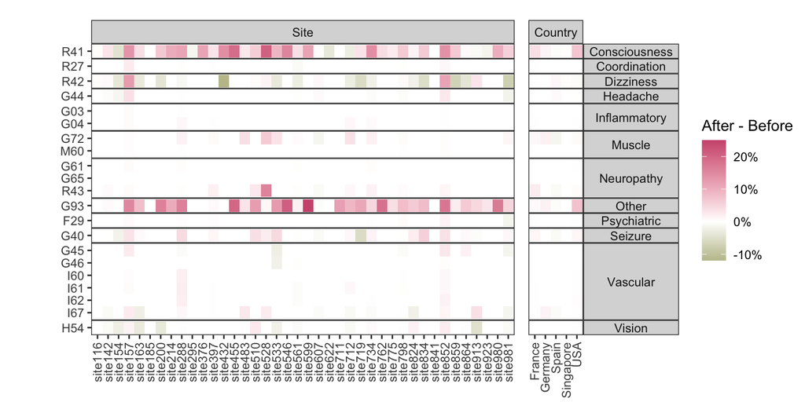

```r
diff_code_loc <- diff_code %>%
  bind_rows(diff_code_country)

diff_heat <- diff_code_loc %>%
  ggplot(aes(y = fct_rev(icd), x = location, fill = percent_diff)) +
  geom_tile() +
  labs(y = NULL, x = NULL, fill = 'After - Before') +
  scale_x_discrete() +
  scale_fill_gradient2(#009392,#39b185,#9ccb86,#e9e29c,#eeb479,#e88471,#cf597e
    low = '#798234',
    high = '#cf597e',
    labels = scales::percent_format(accuracy = 1)) +
  facet_grid(rows = vars(`Neurological Disease Category`),
             cols = vars(fct_rev(loc_type)), space = 'free', scales = 'free') +
  heat_theme_bottom() +
  theme(plot.margin = unit(c(1,0.2,0.2,3), "lines")) +
  NULL
diff_heat
```

```r
# ggsave('figs/icd_diff_heat_sitemap.png', diff_heat_site, height = 4, width = 8)
```

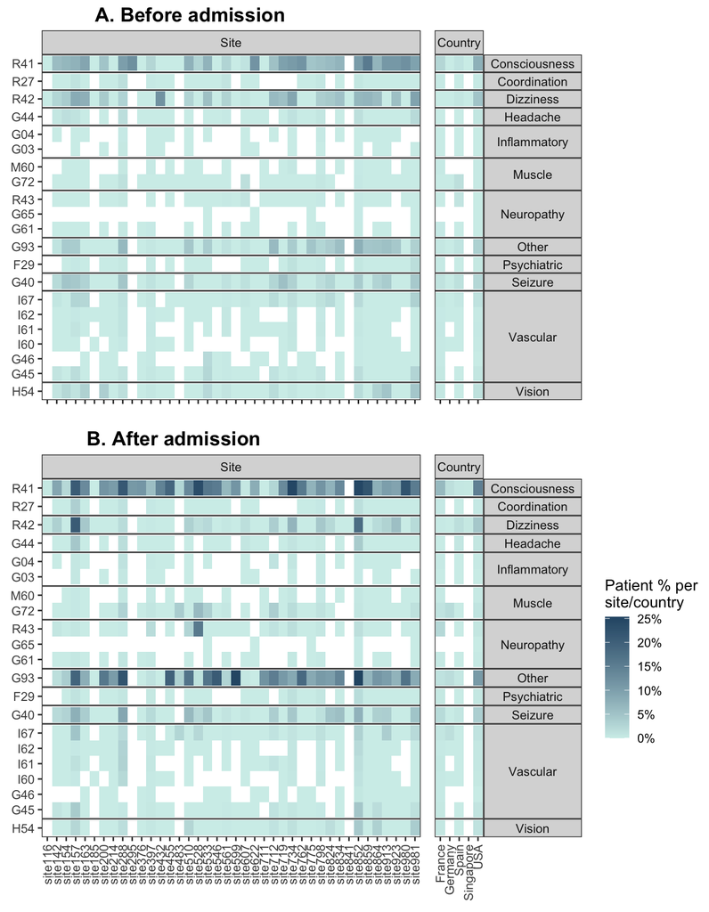

```r
before_code_prev <- diff_code_loc %>%
  ggplot(aes(y = icd, x = location, fill = `Before admission`)) +
  geom_tile() +
  labs(y = NULL, x = NULL, fill = 'Patient % per
site/country') +
  #f6d2a9,#f5b78e,#f19c7c,#ea8171,#dd686c,#ca5268,#b13f64
  scale_fill_gradient(
    low = '#d1eeea', high = '#2a5674',
    labels = scales::percent_format(accuracy = 1),
    limits = c(0, max(diff_code_loc$`After admission`)),
    guide = guide_legend(override.aes = list(fill = "white"))) +
  scale_x_discrete() +
  facet_grid(rows = vars(`Neurological Disease Category`),
             cols = vars(fct_rev(loc_type)), space = 'free', scale = 'free') +
  heat_theme_top() +
  NULL

after_code_prev <- diff_code_loc %>%
  ggplot(aes(y = icd, x = location, fill = `After admission`)) +
  geom_tile() +
  labs(y = NULL, x = NULL, fill = 'Patient % per
site/country') +
  scale_x_discrete() +
  scale_fill_gradient(low = '#d1eeea', high = '#2a5674',
                      labels = scales::percent_format(accuracy = 1),
                      limits = c(0, max(diff_code_loc$`After admission`))) +
  facet_grid(rows = vars(`Neurological Disease Category`),
             cols = vars(fct_rev(loc_type)), space = 'free', scale = 'free') +
  heat_theme_bottom() +
  theme(legend.title = element_text(hjust = 0)) +
  NULL

heats <- cowplot::plot_grid(before_code_prev, after_code_prev, ncol = 1,
                            rel_heights = c(1, 1.15),
                   labels = c('A. Before admission', 'B. After admission'))
heats
```

```r
ggsave('figs/icd_heatmap.png', heats, height = 10, width = 9)
ggsave('figs/tiffs/efig_1.tiff', heats, height = 10, width = 9, dpi = 300)
```

### Hypothesis testing

```r
my_t <- function(icdi){
  diff_icd <- diff_code %>% filter(icd == icdi)
  data.frame(
    icd = icdi,
    t.test(diff_icd$percent_diff) %>%
    broom::tidy()
  )
}
prevalence_stats <- unique(diff_code$icd) %>%
  lapply(my_t) %>%
  bind_rows()
prevalence_stats$p_value_holm <-  p.adjust(prevalence_stats$p.value, 'holm')
prevalence_stats$p_value_bh <- p.adjust(prevalence_stats$p.value, 'BH')
prevalence_stats %>%
  filter(p_value_bh < 0.05)
```

```
##   icd   estimate statistic      p.value parameter   conf.low  conf.high
## 1 R41 0.05765947  5.652728 1.705131e-06        38 0.03701006 0.07830888
## 2 G93 0.08116207  6.897838 4.471201e-08        36 0.05729890 0.10502525
##              method alternative p_value_holm   p_value_bh
## 1 One Sample t-test   two.sided 3.239748e-05 1.705131e-05
## 2 One Sample t-test   two.sided 8.942402e-07 8.942402e-07
```

```r
check = diff_code %>%
  filter(loc_type == 'Site', icd == 'G93') %>%
  left_join(diag_icd_10 %>% select(siteid, Country) %>% distinct() %>% mutate(siteid = tolower(siteid)),
            by = c('location' = 'siteid'))
check %>% group_by(Country) %>%
  summarise(country_diff = mean(percent_diff), .groups = 'drop')
```

```
## # A tibble: 4 x 2
##   Country country_diff
##   <chr>          <dbl>
## 1 France       0.00850
## 2 Germany      0.0161
## 3 Spain       -0.00422
## 4 USA          0.0924
```

### Prevalence change table

```r
prevalence_stats %>%
  arrange(desc(estimate)) %>%
  mutate(ci = paste0('(', round(conf.low*100, 2), '%, ',
                     round(conf.high*100, 2), '%)')) %>%
  select(- c(parameter, method, alternative, conf.low, conf.high)) %>%
  datatable(rownames = FALSE, filter = 'top') %>%
  formatRound(c('statistic'), 1) %>%
  formatPercentage('estimate', 1) %>%
  formatSignif(c('p.value', 'p_value_holm', 'p_value_bh'), 3) %>%
  {.}
```

| icd | estimate | statistic | p.value | p_value_holm | p_value_bh | ci |
| --- | --- | --- | --- | --- | --- | --- |
| G93 | 0.0811620718432847 | 6.89783792771819 | 4.4712008178107e-08 | 8.94240163562139e-07 | 8.94240163562139e-07 | (5.73%, 10.5%) |
| R41 | 0.0576594701372462 | 5.65272777888842 | 1.70513073539007e-06 | 3.23974839724113e-05 | 1.70513073539007e-05 | (3.7%, 7.83%) |
| R43 | 0.00809391016130696 | 1.51657602689167 | 0.140199852100518 | 1 | 0.260110040552307 | (-0.28%, 1.9%) |
| G40 | 0.00712324165042782 | 2.19253227284904 | 0.0348879842683911 | 0.558207748294258 | 0.139551937073565 | (0.05%, 1.37%) |
| G72 | 0.00676570748506837 | 2.58992071946571 | 0.0143319589316946 | 0.257975260770502 | 0.0955463928779638 | (0.14%, 1.21%) |
| I61 | 0.00171595248327483 | 1.6065275947678 | 0.121801399227584 | 1 | 0.260110040552307 | (-0.05%, 0.39%) |
| G04 | 0.00165436395746529 | 2.34196111637672 | 0.0308821663774025 | 0.524996828415842 | 0.139551937073565 | (0.02%, 0.31%) |
| I60 | 0.00160733338828793 | 1.53882756658591 | 0.140334778874364 | 1 | 0.260110040552307 | (-0.06%, 0.38%) |
| I62 | 0.0013308158101072 | 1.33914337058105 | 0.19257329280177 | 1 | 0.296266604310415 | (-0.07%, 0.34%) |
| I67 | 0.00130720056642843 | 0.661710302825092 | 0.512616913405165 | 1 | 0.569574348227961 | (-0.27%, 0.53%) |

[output cut: 11 more lines]

```r
prevalence_stats %>%
  write_csv('results/icd10_prevalence_stats.csv')
```

### Compute confidence inverval

of the mean proportion of patients diagnosed with each ICD

```r
alpha_threshold <- qnorm(0.975)

ci_prevalence <- code_prevalence %>%
  group_by(time, full_icd) %>%
  add_count() %>%
  summarise(
    mean_prop = mean(percent_pats_site, na.rm = T),
    sd_prob = sd(percent_pats_site, na.rm = T),
    n = mean(n),
    me_prop = alpha_threshold * sd_prob / sqrt(n)
  ) %>%
  ungroup()
```

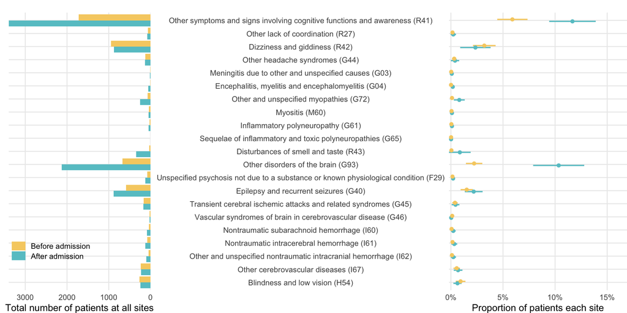

```r
icd_time <- diag_icd_10 %>%
  mutate(time = fct_relevel(time, c('After admission', 'Before admission'))) %>%
  group_by(full_icd, time) %>%
  summarise(pats_icd_time = sum(num_patients_icd, na.rm = T), .groups = 'drop')
# sorted_icds <- icd_time %>%
#   filter(time == 'After admission') %>%
#   arrange(pats_icd_time) %>%
#   pull(full_icd)
# sorted_icds <- code_prevalence %>%
#   ungroup() %>%
#   select(time, percent_pats_site, full_icd, siteid) %>%
#   pivot_wider(names_from = time, values_from = percent_pats_site,
#               values_fill = list(percent_pats_site = 0)) %>%
#   group_by(full_icd) %>%
#   summarise(after = mean(`After admission`, na.rm = T),
#          before = mean(`Before admission`, na.rm = T),
#          diff_prev = after - before,
#          .groups = 'drop') %>%
#   arrange(diff_prev) %>%
#   pull(full_icd)
sorted_icds <- code_prevalence %>%
  distinct(full_icd, icd, `Neurological Disease Category`) %>%
  arrange(desc(`Neurological Disease Category`), desc(icd)) %>%
  pull(full_icd)

total_icd <- icd_time %>%
  ggplot(aes(x = pats_icd_time, y = fct_relevel(full_icd, sorted_icds), fill = time)) +
  scale_fill_carto_d(palette = 4, guide = guide_legend(reverse = TRUE)) +
  geom_col(position = 'dodge') +
  theme_minimal() +
  scale_x_reverse(expand = expansion(add = c(0,0))) +
  scale_y_discrete(labels = NULL) +
  theme(legend.position = c(0.3, 0.15),
        panel.grid.minor = element_blank(),
        legend.title = element_blank(),
        legend.key.height = unit(4, 'mm'),
        plot.margin = margin(t = 1, r = 0.5, l = 0.5, unit = 'lines')) +
  labs(x = 'Total number of patients at all sites', y = NULL)

percent_icd <-
  ci_prevalence %>%
  ggplot(aes(group = time)) +
  ggstance::geom_pointrangeh(
    aes(x = mean_prop,
        y = fct_relevel(full_icd, sorted_icds),
        xmin = mean_prop - me_prop,
        xmax = mean_prop + me_prop,
        color = time),
    position = position_dodge(width = 0.3),
    stroke = 0.1, fatten = 3, size = 0.7
  ) +
  scale_color_carto_d(palette = 4, guide = NULL) +
  theme_minimal() +
  theme(legend.position = c(0.75, 0.1),
        panel.grid.minor = element_blank(),
        legend.title = element_blank(),
        axis.text.y = element_text(hjust = 0.5),
        plot.margin = margin(t = 1, unit = 'lines')) +
  scale_x_continuous(expand = expansion(add = c(0, 0.03)),
                     labels = scales::percent_format(accuracy = 1)) +
  labs(x = 'Proportion of patients each site', y = NULL)

icd_prevalence_plots <- cowplot::plot_grid(total_icd, percent_icd, ncol = 2,
                                           rel_widths = c(1, 3))
icd_prevalence_plots
```

```r
# ggsave('figs/icd_prevalence.png', icd_prevalence_plots, height = 5, width = 10)
```

```r
plot_grid(diff_heat, icd_prevalence_plots, rel_heights = c(1, 0.85),
          ncol = 1, labels = 'AUTO') %>%
  ggsave('figs/icd_prevalence_AB.png', ., height = 8, width = 9.7)

plot_grid(diff_heat, icd_prevalence_plots, rel_heights = c(1, 0.85),
          ncol = 1, labels = 'AUTO') %>%
ggsave('figs/tiffs/fig_3.tiff', ., height = 8, width = 9.7, dpi = 300)
```

```r
diff_code %>%
  filter(icd == 'R41') %>%
  ungroup() %>%
  count(percent_diff > 0)
```

```
## # A tibble: 2 x 2
##   `percent_diff > 0`     n
##   <lgl>              <int>
## 1 FALSE                  9
## 2 TRUE                  30
```

```r
diff_code %>%
  filter(icd == 'G93') %>%
  ungroup() %>%
  count(percent_diff > 0)
```

```
## # A tibble: 2 x 2
##   `percent_diff > 0`     n
##   <lgl>              <int>
## 1 FALSE                  6
## 2 TRUE                  31
```

```r
diff_code %>%
  filter(icd == 'R42') %>%
  ungroup() %>%
  count(percent_diff > 0)
```

```
## # A tibble: 2 x 2
##   `percent_diff > 0`     n
##   <lgl>              <int>
## 1 FALSE                 28
## 2 TRUE                  10
```

# Severity descriptive statistics

What ICD code has the most number severe patients? Sites with more severe patients?

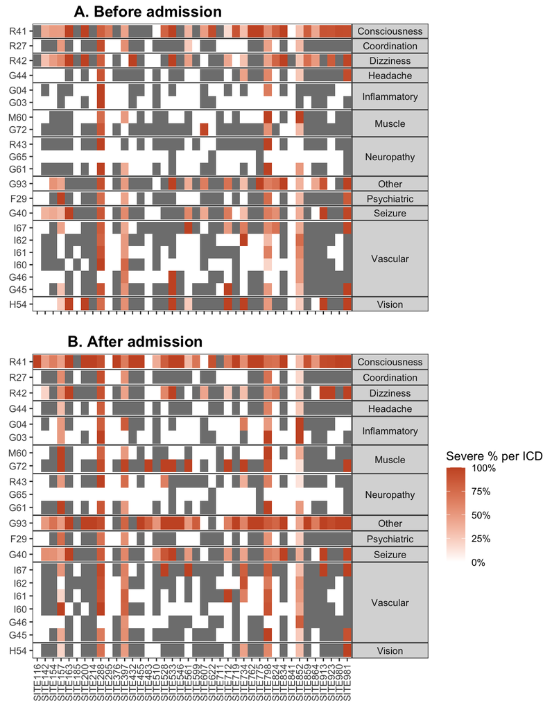

```r
severe_code <- diag_icd_10 %>%
  # filter(siteid != 'SITE309') %>%
  mutate(percent_severe_site = num_patients_ever_severe_icd1/num_patients_icd,
         siteid = as.factor(siteid))

severe_bef_heat <- severe_code %>%
  filter(time == 'Before admission') %>%
  ggplot(aes(y = icd, x = siteid, fill = percent_severe_site)) +
  geom_tile() +
  labs(y = NULL, x = NULL, fill = 'Severe % per ICD') +
  #3d5941,#778868,#b5b991,#f6edbd,#edbb8a,#de8a5a,#ca562c
  scale_fill_gradient(
    # low = '#f6d2a9', high = '#b13f64',
    low = 'white', high = '#ca562c',
    guide = guide_legend(override.aes = list(fill = "white")),
    ) +
  scale_x_discrete() +
  facet_grid(rows = vars(`Neurological Disease Category`), space = 'free', scale = 'free') +
  heat_theme_top() +
  NULL

severe_aft_heat <- severe_code %>%
  filter(time == 'After admission') %>%
  ggplot(aes(y = icd, x = siteid, fill = percent_severe_site)) +
  geom_tile() +
  labs(y = NULL, x = NULL, fill = 'Severe % per ICD') +
  scale_x_discrete() +
  #3d5941,#778868,#b5b991,#f6edbd,#edbb8a,#de8a5a,#ca562c
  scale_fill_gradient(
    low = 'white', high = '#ca562c',
    labels = scales::percent_format(accuracy = 1)) +
  facet_grid(rows = vars(`Neurological Disease Category`), space = 'free', scale = 'free') +
  heat_theme_bottom() +
  NULL

severe_heats <- cowplot::plot_grid(severe_bef_heat, severe_aft_heat, ncol = 1,
                            rel_heights = c(1, 1.15),
                   labels = c('A. Before admission', 'B. After admission'))
severe_heats
```

```r
ggsave('figs/icd_severe_heatmap.png', severe_heats, height = 10, width = 7)
```

# Severity enrichment analysis

## Null hypothesis

For each ICD code, the proportion of severe patients who were diagnosed with that ICD code is similar to the proportion of never-severe patients who were diagnosed with that same ICD code.

For the sake of simplicity in this notebook, we’re going to denote patients whose symptoms have been categorized as severe (based on respiratory status +/- requiring ICU) at least once as *severe patients*, and patients whose symptoms have NEVER been categorized as severe as *non-severe patients*.

For each ICD code, we computed the expected number of *severe patients* by multiplying the proportion of *non-severe patients* who were diagnosed with that code with the total number of *severe patients*. We performed an enrichment analysis to examine the difference of *severe patients* proportions across ICD codes. We calculated each ICD code’s enrichment by dividing the observed proportion of honorees by the expected proportion of honorees and reported a value of log2 enrichment (LOE) and its 95% confidence intervals. The 95% confidence interval of the LOE was estimated using the Poisson model method [@isbn:9780849394447].

```r
contingency_continent <- diag_icd_10 %>%
  mutate(continent = ifelse(Country == 'USA', 'US', 'NonUS')) %>%
  group_by(full_icd, time, continent) %>%
  summarise(across(contains('severe'), .fns = sum, na.rm = T), .groups = 'drop') %>%
  mutate(Observed = num_patients_ever_severe_icd1,
         num_non_severe = num_patients_never_severe_icd1 + num_patients_never_severe_icd0,
         num_severe = num_patients_ever_severe_icd1 + num_patients_ever_severe_icd0,
         Expected = num_patients_never_severe_icd1/num_non_severe*num_severe,
         over_sev = Observed - Expected)

ind_fish <- contingency_continent %>%
  filter(!is.na(Expected), num_patients_never_severe_icd0 >= 0) %>%
  select(full_icd, time, continent,
         num_patients_never_severe_icd0,
         num_patients_never_severe_icd1,
         num_patients_ever_severe_icd0,
         num_patients_ever_severe_icd1) %>%
  group_by(full_icd, time, continent) %>%
  nest() %>%
  mutate(fish = map(data, my_fish)) %>%
  dplyr::select(-data) %>%
  unnest(cols = c(fish)) %>%
  mutate(upper = ifelse(is.na(upper), Inf, upper)) %>%
  mutate(lci = paste0('(', round(log2(lower), 1), ', ',
                     round(log2(upper), 1), ')'),
         lestimate = log2(estimate))
ind_fish$`P value (Holm)` <-  p.adjust(ind_fish$p_value, 'holm')
ind_fish$`P value (FDR)` <- p.adjust(ind_fish$p_value, 'BH')

madata <- contingency_continent %>%
  left_join(ind_fish, by = c('full_icd', 'continent', 'time')) %>%
  filter(time == 'After admission') %>%
  mutate(
    distance_to_null = case_when(
      lower > 1 ~ lower - 1,
      TRUE ~ upper - 2
    ),
    presentation = case_when(
      lower > 1 & `P value (FDR)` < 0.05 ~ '#d46780',
      upper < 1 & `P value (FDR)` < 0.05 ~ '#798234',
      TRUE ~ 'grey20'
    ),
    upper = ifelse(is.na(upper), Inf, upper))

plot_obs_exp <- madata %>%
  mutate(lestimate = log2(estimate),
         llower = log2(lower),
         lupper = log2(upper)) %>%
  select(full_icd, continent, lestimate, llower, lupper, presentation, over_sev, Observed, Expected) %>%
  pivot_longer(- c(full_icd, continent, presentation, over_sev), names_to = 'type') %>%
  mutate(subtype = ifelse(type == 'Expected' | type == 'Observed',
                          'Sqrt(number of honorees)',
                          'Log2 enrichment, 95% CI')) %>%
  pivot_wider(names_from = type, values_from = value) %>%
  mutate(presentation = as.factor(presentation),
         full_icd = fct_relevel(full_icd, sorted_icds))

sorted_icds <- madata %>%
  filter(time == 'After admission') %>%
  group_by(full_icd) %>%
  summarise(total_expected = sum(Expected), .groups = 'drop') %>%
  arrange(total_expected) %>%
  pull(full_icd)

plot_obs_exp_right <- plot_obs_exp %>% filter(subtype == 'Sqrt(number of honorees)')
plot_obs_exp_left <- plot_obs_exp %>% filter(subtype != 'Sqrt(number of honorees)')

enrichment_plot_us <- plot_enrich(
  plot_obs_exp_left %>% filter(continent == 'US'),
  plot_obs_exp_right %>% filter(continent == 'US') %>%
    slice(match(sorted_icds, full_icd)),
  nudge = 2.5)
enrichment_plot_nonus <- plot_enrich(
  plot_obs_exp_left %>% filter(continent == 'NonUS'),
  plot_obs_exp_right %>% filter(continent == 'NonUS') %>% slice(match(sorted_icds, full_icd)),
  nudge = 2.5)
enrichment_plot_cont <- cowplot::plot_grid(
  enrichment_plot_us,
  enrichment_plot_nonus,
  ncol = 1, hjust = -0.05,
  labels = c('A. US sites', 'B. Non-US sites')
)



ggsave('figs/icd_severe_after_us_nonus.png', enrichment_plot_cont, width = 9.5, height = 7)
ggsave('figs/tiffs/efig_2.tiff', enrichment_plot_cont, width = 9.5, height = 7, dpi = 300)

madata %>%
  write_csv('results/icd10_fish_tab_us_nonus.csv')
```

## Before and after admission

```r
contingency_df <- diag_icd_10 %>%
  # filter(time == 'Before admission') %>%
  select(- c(num_patients_all, num_patients_ever_severe, num_patients_never_severe)) %>%
  group_by(full_icd, time) %>%
  summarise(across(contains('severe'), .fns = sum, na.rm = T), .groups = 'drop') %>%
  mutate(Observed = num_patients_ever_severe_icd1,
         num_non_severe = num_patients_never_severe_icd1 + num_patients_never_severe_icd0,
         num_severe = num_patients_ever_severe_icd1 + num_patients_ever_severe_icd0,
         Expected = num_patients_never_severe_icd1/num_non_severe*num_severe,
         over_sev = Observed - Expected)

nested_obs_exp <- contingency_df %>%
  select(full_icd,
         time,
         num_patients_never_severe_icd0,
         num_patients_never_severe_icd1,
         num_patients_ever_severe_icd0,
         num_patients_ever_severe_icd1) %>%
  group_by(full_icd, time) %>%
  nest()

fish_obs_exp <- nested_obs_exp %>%
  mutate(fish = map(data, my_fish)) %>%
  dplyr::select(-data) %>%
  unnest(cols = c(fish)) %>%
  mutate(upper = ifelse(is.na(upper), Inf, upper)) %>%
  mutate(lci = paste0('(', round(log2(lower), 1), ', ',
                     round(log2(upper), 1), ')'),
         lestimate = log2(estimate))
```

```
## Warning: Problem with `mutate()` input `fish`.
## ℹ Chi-squared approximation may be incorrect
## ℹ Input `fish` is `map(data, my_fish)`.
## ℹ The error occurred in group 36: full_icd = "Sequelae of inflammatory and toxic polyneuropathies (G65)", time = "Before admission".
```

```
## Warning in chisq.test(xx, correct = correction): Chi-squared approximation may
## be incorrect
```

```r
fish_obs_exp$`P value (Holm)` <-  p.adjust(fish_obs_exp$p_value, 'holm')
fish_obs_exp$`P value (FDR)` <- p.adjust(fish_obs_exp$p_value, 'BH')
fish_obs_exp %>%
  filter(`P value (FDR)` < 0.05,
         time == 'After admission')
```

```
## # A tibble: 13 x 10
## # Groups:   full_icd, time [13]
##    full_icd time  estimate lower upper  p_value lci   lestimate `P value (Holm)`
##    <chr>    <chr>    <dbl> <dbl> <dbl>    <dbl> <chr>     <dbl>            <dbl>
##  1 Blindne… Afte…    0.771 0.669 0.889 5.33e- 5 (-0.…    -0.375         1.71e- 3
##  2 Dizzine… Afte…    0.724 0.669 0.785 6.01e-20 (-0.…    -0.465         2.34e-18
##  3 Encepha… Afte…    1.37  1.17  1.60  3.09e- 3 (0.2…     0.455         8.33e- 2
##  4 Nontrau… Afte…    1.36  1.23  1.51  6.81e- 6 (0.3…     0.446         2.38e- 4
##  5 Nontrau… Afte…    1.28  1.10  1.48  7.53e- 3 (0.1…     0.355         1.96e- 1
##  6 Other a… Afte…    1.72  1.67  1.77  4.21e-46 (0.7…     0.780         1.72e-44
##  7 Other a… Afte…    1.34  1.20  1.50  8.67e- 5 (0.3…     0.425         2.69e- 3
##  8 Other c… Afte…    1.24  1.13  1.35  4.75e- 5 (0.2…     0.307         1.57e- 3
##  9 Other d… Afte…    1.36  1.32  1.40  1.34e-74 (0.4…     0.442         5.63e-73
## 10 Other h… Afte…    0.531 0.409 0.690 1.34e- 9 (-1.…    -0.913         4.97e- 8
## 11 Other s… Afte…    1.22  1.19  1.25  1.52e-40 (0.2…     0.283         6.08e-39
## 12 Transie… Afte…    0.554 0.444 0.693 6.01e-11 (-1.…    -0.851         2.28e- 9
## 13 Unspeci… Afte…    0.559 0.434 0.720 1.29e- 8 (-1.…    -0.839         4.64e- 7
## # … with 1 more variable: `P value (FDR)` <dbl>
```

While the Warning messages mentioned Chi-squared, the p-values were actually calculated using Fisher’s Exact test (see more in `epitools::tab2by2.test()`).

Note: small number of observations for ICD-10 code G04, G03, G65:

```r
contingency_df %>%
  filter(grepl('G04|G03|G65', full_icd)) %>%
  datatable()
```

|  | full_icd | time | num_patients_ever_severe_icd1 | num_patients_never_severe_icd1 | num_patients_never_severe_icd0 | num_patients_ever_severe_icd0 | Observed | num_non_severe | num_severe | Expected | over_sev |
| --- | --- | --- | --- | --- | --- | --- | --- | --- | --- | --- | --- |
| 1 | Encephalitis, myelitis and encephalomyelitis (G04) | After admission | 42 | 15 | 12051 | 14011 | 42 | 12066 | 14053 | 17.4701640974639 | 24.5298359025361 |
| 2 | Encephalitis, myelitis and encephalomyelitis (G04) | Before admission | 3 | 5 | 12061 | 14050 | 3 | 12066 | 14053 | 5.82338803248798 | -2.82338803248798 |
| 3 | Meningitis due to other and unspecified causes (G03) | After admission | 10 | 5 | 10354 | 12908 | 10 | 10359 | 12918 | 6.23515783376774 | 3.76484216623226 |
| 4 | Meningitis due to other and unspecified causes (G03) | Before admission | 4 | 6 | 8238 | 11847 | 4 | 8244 | 11851 | 8.62518195050946 | -4.62518195050946 |
| 5 | Sequelae of inflammatory and toxic polyneuropathies (G65) | After admission | 0 | 1 | 836 | 1971 | 0 | 837 | 1971 | 2.35483870967742 | -2.35483870967742 |
| 6 | Sequelae of inflammatory and toxic polyneuropathies (G65) | Before admission | 0 | 1 | 836 | 1971 | 0 | 837 | 1971 | 2.35483870967742 | -2.35483870967742 |

The full table with all ICD codes and their corresponding enrichment can be browsed interactively below:

```r
library(DT)
fish_tab <- fish_obs_exp  %>%
  left_join(contingency_df, by = c('full_icd', 'time')) %>%
  select(full_icd, time, Observed, Expected, over_sev,
         estimate, lestimate, lci, p_value,
         `P value (Holm)`, `P value (FDR)`) %>%
  arrange(desc(over_sev)) %>%
  rename('ICD' = 'full_icd',
         'Observed - Expected' = 'over_sev',
         'Enrichment' = 'estimate',
         'Log2(enrichment)' = 'lestimate',
         '95% Confidence interval' = 'lci',
         'P value (raw)' = 'p_value')

fish_tab %>%
  datatable(rownames = FALSE, filter = 'top') %>%
  formatRound(c('Observed', 'Expected', 'Observed - Expected',
                'Enrichment', 'Log2(enrichment)'), 1) %>%
  formatSignif(c('P value (raw)', 'P value (Holm)', 'P value (FDR)'), 3) %>%
  {.}
```

| ICD | time | Observed | Expected | Observed - Expected | Enrichment | Log2(enrichment) | 95% Confidence interval | P value (raw) | P value (Holm) | P value (FDR) |
| --- | --- | --- | --- | --- | --- | --- | --- | --- | --- | --- |
| Other disorders of the brain (G93) | After admission | 1595 | 691.70199308671 | 903.29800691329 | 1.35844843075135 | 0.441959799191523 | (0.4, 0.5) | 1.34157061841076e-74 | 5.63459659732517e-73 | 5.63459659732517e-73 |
| Other symptoms and signs involving cognitive functions and awareness (R41) | After admission | 2270 | 1446.98593986589 | 823.014060134112 | 1.21642594841696 | 0.282648496927897 | (0.2, 0.3) | 1.52027311033513e-40 | 6.08109244134051e-39 | 2.12838235446918e-39 |
| Other and unspecified myopathies (G72) | After admission | 239 | 14.0028087755257 | 224.997191224474 | 1.71721427707199 | 0.78007007264292 | (0.7, 0.8) | 4.20629467403775e-46 | 1.72458081635548e-44 | 8.83321881547927e-45 |
| Other cerebrovascular diseases (I67) | After admission | 157 | 88.3753968839991 | 68.6246031160009 | 1.23679151061174 | 0.306602321690741 | (0.2, 0.4) | 4.74731686162863e-05 | 0.00156661456433745 | 0.000199387308188403 |
| Epilepsy and recurrent seizures (G40) | After admission | 528 | 462.577085026224 | 65.4229149737756 | 1.05851148804024 | 0.0820369270202695 | (0, 0.2) | 0.0535592775801087 | 1 | 0.107118555160217 |
| Nontraumatic intracerebral hemorrhage (I61) | After admission | 92 | 37.9035426980198 | 54.0964573019802 | 1.36181008771589 | 0.445525525219275 | (0.3, 0.6) | 6.80953424456087e-06 | 0.000238333698559631 | 3.57500547839446e-05 |
| Other and unspecified nontraumatic intracranial hemorrhage (I62) | After admission | 76 | 32.4949868887861 | 43.5050131112139 | 1.34287648967455 | 0.425326619785358 | (0.3, 0.6) | 8.67164653843081e-05 | 0.00268821042691355 | 0.000303507628845078 |
| Other and unspecified myopathies (G72) | Before admission | 52 | 17.9023736885185 | 34.0976263114815 | 1.40524134710792 | 0.490817931423825 | (0.3, 0.7) | 0.000157055399461103 | 0.00471166198383308 | 0.000507409752105101 |
| Nontraumatic subarachnoid hemorrhage (I60) | After admission | 56 | 29.8532374100719 | 26.1467625899281 | 1.2787933750179 | 0.354783175151011 | (0.1, 0.6) | 0.00753185858794788 | 0.195828323286645 | 0.018608121217283 |
| Disturbances of smell and taste (R43) | After admission | 201 | 175.338208409506 | 25.6617915904936 | 1.06030523159806 | 0.0844796352826116 | (0, 0.2) | 0.226230029365827 | 1 | 0.327643490805681 |

[output cut: 32 more lines]

```r
fish_tab %>%
  write_csv('results/icd10_fish_tab.csv')

fish_obs_exp %>%
  filter(`P value (FDR)` < 0.05) %>%
  arrange(time) %>%
  mutate(lestimate = round(lestimate, 2),
         drr = round((estimate - 1)*100, 0),
         lower_drr = (lower - 1)*100,
         upper_drr = (upper - 1)*100,
         ci_drr = paste0('(', round(lower_drr, 0), ', ',
                     round(upper_drr, 0), ')'),
         p_fdr = format(`P value (FDR)`, digits = 2)) %>%
  select(time, full_icd, lestimate, drr, ci_drr, p_fdr) %>%
  write_csv('results/icd10_signi.csv')
```

### Compute enrichment from proportion comparisons

```r
filtered_obs_exp <- contingency_df %>%
  left_join(fish_obs_exp, by = c('full_icd', 'time')) %>%
  mutate(
    distance_to_null = case_when(
      lower > 1 ~ lower - 1,
      TRUE ~ upper - 2
    ),
    presentation = case_when(
      lower > 1 & `P value (FDR)` < 0.05 ~ '#d46780',
      upper < 1 & `P value (FDR)` < 0.05 ~ '#798234',
      TRUE ~ 'grey20'
    )) %>%
  {.}
```

```r
# plot_obs_exp_before <- plot_obs_exp_left
# sorted_icds <- rev(as.character(filtered_obs_exp$full_icd))
# sorted_icds <- filtered_obs_exp %>%
#   select(full_icd, time, estimate) %>%
#   pivot_wider(names_from = time, values_from = estimate) %>%
#   mutate(diff_est = log2(`After admission`) - log2(`Before admission`),
#          diff_est = ifelse(is.na(diff_est), -Inf, diff_est),
#          full_icd = as.character(full_icd)) %>%
#   arrange(diff_est) %>%
#   pull(full_icd)
sorted_icds <- filtered_obs_exp %>%
  filter(time == 'After admission') %>%
  arrange(Expected) %>%
  pull(full_icd)

plot_obs_exp <- filtered_obs_exp %>%
  mutate(lestimate = log2(estimate),
         llower = log2(lower),
         lupper = log2(upper)) %>%
  select(full_icd, time, lestimate, llower, lupper, presentation, over_sev, Observed, Expected) %>%
  pivot_longer(- c(full_icd, time, presentation, over_sev), names_to = 'type') %>%
  mutate(subtype = ifelse(type == 'Expected' | type == 'Observed',
                          'Sqrt(number of honorees)',
                          'Log2 enrichment, 95% CI')) %>%
  pivot_wider(names_from = type) %>%
  mutate(presentation = as.factor(presentation),
         full_icd = fct_relevel(full_icd, sorted_icds))

plot_obs_exp_right <- plot_obs_exp %>% filter(subtype == 'Sqrt(number of honorees)')
plot_obs_exp_left <- plot_obs_exp %>% filter(subtype != 'Sqrt(number of honorees)')
```

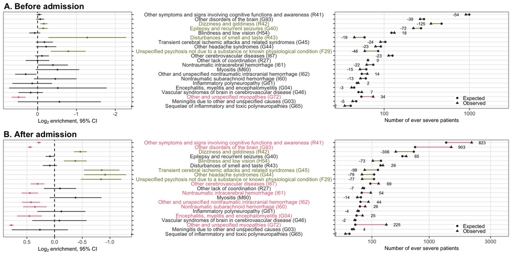

```r
enrichment_plot_before <- plot_enrich(
  plot_obs_exp_left %>% filter(time == 'Before admission'),
  plot_obs_exp_right %>% filter(time == 'Before admission') %>%
    slice(match(sorted_icds, full_icd)),
  nudge = 2.5)
enrichment_plot_after <- plot_enrich(
  plot_obs_exp_left %>% filter(time == 'After admission'),
  plot_obs_exp_right %>% filter(time == 'After admission') %>% slice(match(sorted_icds, full_icd)),
  nudge = 4)
enrichment_plot <- cowplot::plot_grid(
  enrichment_plot_before,
  enrichment_plot_after,
  ncol = 1, hjust = -0.05,
  labels = c('A. Before admission', 'B. After admission')
)
enrichment_plot
```

```r
ggsave('figs/icd_severe_after.png', enrichment_plot_after, width = 9.5, height = 3.5)
ggsave('figs/tiffs/fig_4.tiff', enrichment_plot_after, width = 9.5, height = 3.5, dpi = 300)
```

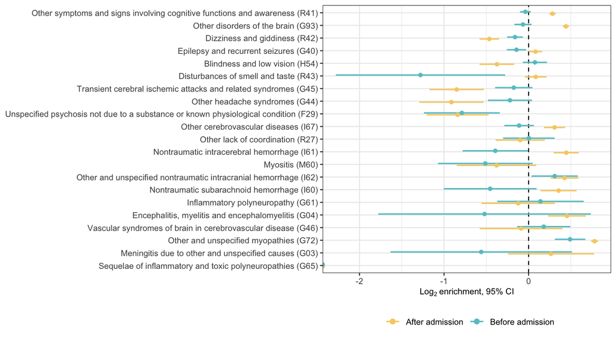

```r
plot_enrich_both <- plot_obs_exp %>%
  ggplot(aes(y = fct_relevel(full_icd, sorted_icds))) +
  geom_vline(aes(xintercept = 0), linetype = 2) +
  ggstance::geom_pointrangeh(
    aes(x = lestimate,
        xmin = llower,
        xmax = lupper,
        color = time),
    position = position_dodge(width = 0.3),
    stroke = 0.1, fatten = 3, size = 0.7
  ) +
  labs(y = NULL, x = bquote(Log[2] ~ 'enrichment, 95% CI')) +
  theme(
    legend.position = 'bottom',
    legend.background = element_blank(),
    axis.title = element_text(size = 9),
    plot.margin = margin(5.5, 2, 5.5, 5.5, unit = 'pt')
  ) +
  scale_color_carto_d(palette = 4, direction = -1) +
  NULL
plot_enrich_both
```

```r
ggsave('figs/icd_severe.png', plot_enrich_both, width = 9, height = 5)
```